# PA 9.2 - Multiclass Classification

Our dataset consists of clinical data from patients who entered the hospital complaining of chest pain (“angina”) during exercise. The information collected includes:

- `age` : Age of the patient
- `sex` : Sex of the patient
- `cp` : Chest Pain type
  - Value 0: asymptomatic
  - Value 1: typical angina
  - Value 2: atypical angina
  - Value 3: non-anginal pain
- `trtbps` : resting blood pressure (in mm Hg)
- `chol` : cholesterol in mg/dl fetched via BMI sensor
- `restecg` : resting electrocardiographic results
  - Value 0: normal
  - Value 1: having ST-T wave abnormality (T wave inversions and/or ST elevation or depression of > 0.05 mV)
  - Value 2: showing probable or definite left ventricular hypertrophy by Estes’ criteria
- `thalach` : maximum heart rate achieved during exercise
- `output` : the doctor’s diagnosis of whether the patient is at risk for a heart attack
  - 0 = not at risk of heart attack
  - 1 = at risk of heart attack

```python
## library imports here
```

```python
import pandas as pd
ha = pd.read_csv("https://www.dropbox.com/s/aohbr6yb9ifmc8w/heart_attack.csv?dl=1")
```

```python
# Get Dummies
ha = pd.get_dummies(ha, columns = ["sex", "restecg", "output"], drop_first = True)
```

```python
# Packages
from sklearn.model_selection import train_test_split, cross_val_score, GridSearchCV
from sklearn.preprocessing import StandardScaler, LabelBinarizer
from sklearn.metrics import confusion_matrix, roc_auc_score, roc_curve, accuracy_score, precision_recall_fscore_support, classification_report, make_scorer
from sklearn.neighbors import KNeighborsClassifier
from sklearn.linear_model import LogisticRegression
from sklearn.discriminant_analysis import LinearDiscriminantAnalysis
from sklearn.tree import DecisionTreeClassifier, plot_tree
import matplotlib.pyplot as plt
```

## Q1: Natural Multiclass Models

Fit a multiclass KNN, Decision Tree, and LDA for the heart disease data; this time predicting the type of chest pain (categories 0 - 3) that a patient experiences. For the decision tree, plot the fitted tree, and interpret the first couple splits.

```python
X = ha.drop("cp", axis = 1)
y = ha["cp"]

# Standardize the variables
scaler = StandardScaler()
X_scaled = scaler.fit_transform(X)

# Split the data into training and test sets
X_train, X_test, y_train, y_test = train_test_split(X_scaled, y, test_size = 0.25, random_state = 321, stratify = y)

knn = KNeighborsClassifier()
param_grid_knn = {"n_neighbors": range(1, 26)}
grid_knn = GridSearchCV(knn, param_grid_knn, cv = 10, scoring = make_scorer(roc_auc_score, multi_class='ovo', average='weighted', response_method='predict_proba'))
grid_knn.fit(X_train, y_train)
best_knn = grid_knn.best_estimator_
best_knn.fit(X_train, y_train)
y_proba_knn = best_knn.predict_proba(X_test)
roc_auc_knn = roc_auc_score(y_test, y_proba_knn, multi_class='ovo', average='weighted')
cv_scores_knn = cross_val_score(best_knn, X_train, y_train, cv = 10, scoring = make_scorer(roc_auc_score, multi_class='ovo', average='weighted', response_method='predict_proba'))
roc_auc_knn_cv = cv_scores_knn.mean()
best_k = grid_knn.best_params_['n_neighbors']
print("Best k Value:", best_k)
print("kNN ROC AUC Metric:", roc_auc_knn)
```

```
Best k Value: 24
kNN ROC AUC Metric: 0.637284203316812
```

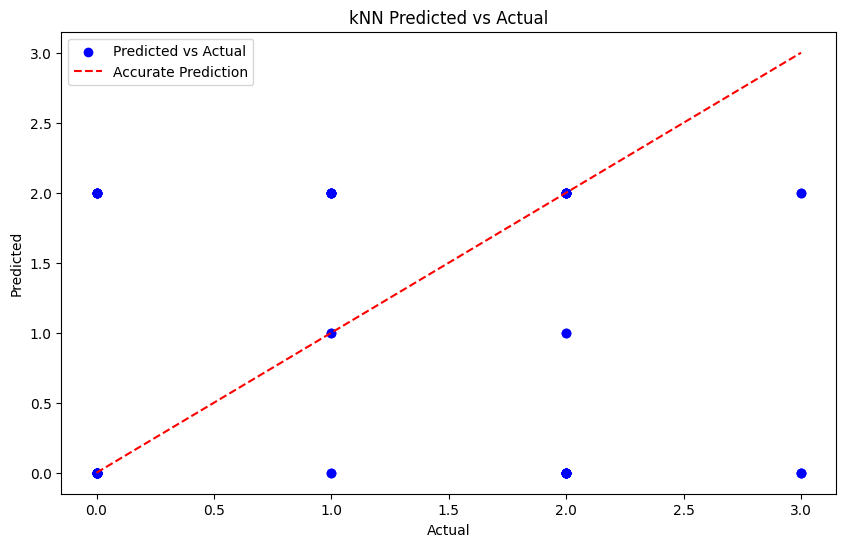

```python
# Plot predicted vs actual
y_pred_knn = best_knn.predict(X_test)
plt.figure(figsize=(10, 6))
plt.scatter(y_test, y_pred_knn
            , color='blue', label='Predicted vs Actual')
plt.plot([0, 3], [0, 3], color='red', linestyle='--', label='Accurate Prediction')
plt.xlabel('Actual')
plt.ylabel('Predicted')
plt.title('kNN Predicted vs Actual')
plt.legend()
plt.show()
```

```python
# Decision Tree
dtree = DecisionTreeClassifier(random_state=321)
param_grid_dt = {"max_depth": range(1, 11)}
grid_dt = GridSearchCV(dtree, param_grid_dt, cv = 10, scoring = make_scorer(roc_auc_score, multi_class='ovo', average='weighted', response_method='predict_proba'))
grid_dt.fit(X_train, y_train)
best_tree = grid_dt.best_estimator_
best_tree.fit(X_train, y_train)
y_proba_dt = best_tree.predict_proba(X_test)
roc_auc_dt = roc_auc_score(y_test, y_proba_dt, multi_class='ovo', average='weighted')
cv_scores_dt = cross_val_score(best_tree, X_train, y_train, cv = 10, scoring = make_scorer(roc_auc_score, multi_class='ovo', average='weighted', response_method='predict_proba'))
roc_auc_dt_cv = cv_scores_dt.mean()
print("Decision Tree ROC AUC Metric:", roc_auc_dt)
```

```
Decision Tree ROC AUC Metric: 0.6764514320220844
```

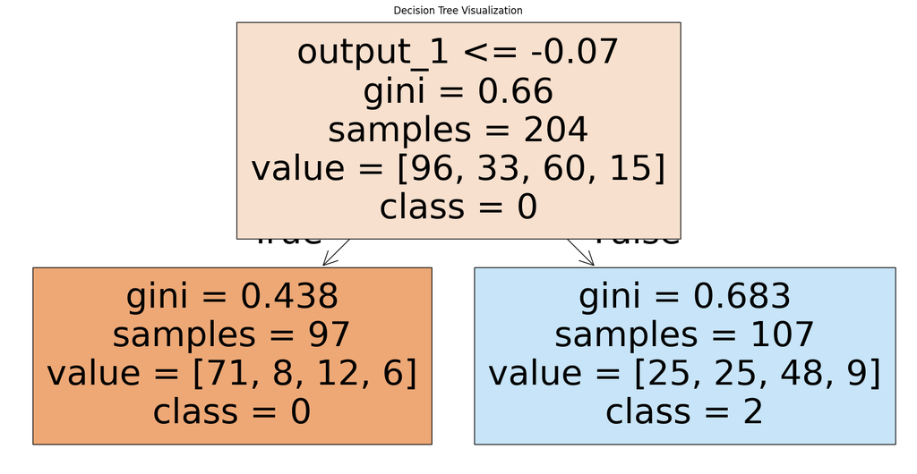

```python
plt.figure(figsize=(20,10))
plot_tree(best_tree, filled=True, feature_names=X.columns, class_names=['0', '1', '2', '3'], max_depth=2)
plt.title("Decision Tree Visualization")
plt.show()
```

```python
# LDA
lda = LinearDiscriminantAnalysis()
lda.fit(X_train, y_train)
y_proba_lda = lda.predict_proba(X_test)
roc_auc_lda = roc_auc_score(y_test, y_proba_lda, multi_class='ovo', average='weighted')
cv_scores_lda = cross_val_score(lda, X_train, y_train, cv = 10, scoring = make_scorer(roc_auc_score, multi_class='ovo', average='weighted', response_method='predict_proba'))
roc_auc_lda_cv = cv_scores_lda.mean()
print("LDA ROC AUC Metric:", roc_auc_lda)
```

```
LDA ROC AUC Metric: 0.6532615884518059
```

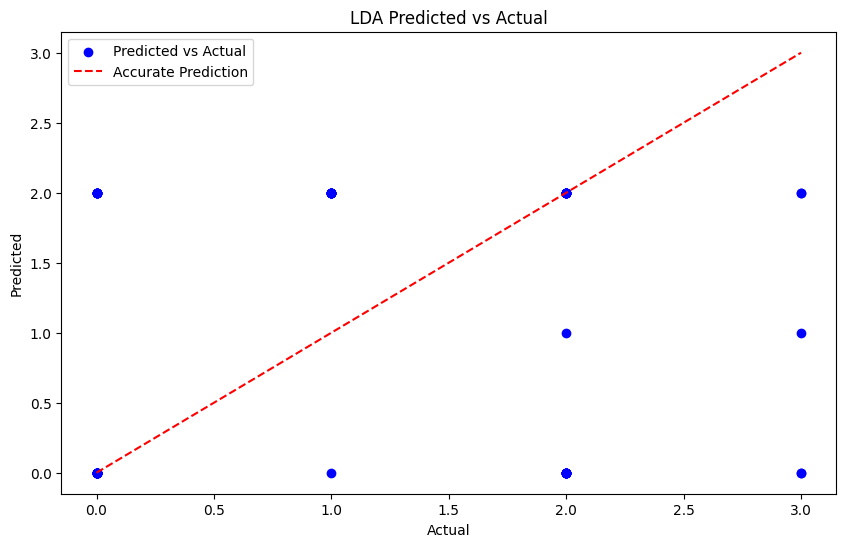

```python
# Plot predicted vs actual
y_pred_lda = lda.predict(X_test)
plt.figure(figsize=(10, 6))
plt.scatter(y_test, y_pred_lda
            , color='blue', label='Predicted vs Actual')
plt.plot([0, 3], [0, 3], color='red', linestyle='--', label='Accurate Prediction')
plt.xlabel('Actual')
plt.ylabel('Predicted')
plt.title('LDA Predicted vs Actual')
plt.legend()
plt.show()
```

## Q2: OvR

Create a new column in the `ha` dataset called `cp_is_3`, which is equal to `1` if the `cp` variable is equal to `3` and `0` otherwise.

Then, fit a Logistic Regression to predict this new target, and report the **F1 Score**.

Repeat for the other three `cp` categories. Which category was the OvR approach best at distinguishing?

```python
from sklearn.metrics import f1_score

ha['cp_is_0'] = (ha['cp'] == 0).astype(int)
X_ovr_0 = X_scaled
y_ovr_0 = ha['cp_is_0']

X_train_ovr_0, X_test_ovr_0, y_train_ovr_0, y_test_ovr_0 = train_test_split(X_ovr_0, y_ovr_0, test_size=0.25, random_state=321, stratify=y_ovr_0)

log_reg_ovr_0 = LogisticRegression(random_state=321)
log_reg_ovr_0.fit(X_train_ovr_0, y_train_ovr_0)

y_pred_ovr_0 = log_reg_ovr_0.predict(X_test_ovr_0)
f1_ovr_0 = f1_score(y_test_ovr_0, y_pred_ovr_0)

print(f"F1 Score for cp_is_0: {f1_ovr_0}")
```

```
F1 Score for cp_is_0: 0.7761194029850746
```

```python
ha['cp_is_1'] = (ha['cp'] == 1).astype(int)
X_ovr_1 = X_scaled
y_ovr_1 = ha['cp_is_1']

X_train_ovr_1, X_test_ovr_1, y_train_ovr_1, y_test_ovr_1 = train_test_split(X_ovr_1, y_ovr_1, test_size=0.25, random_state=321, stratify=y_ovr_1)

log_reg_ovr_1 = LogisticRegression(random_state=321)
log_reg_ovr_1.fit(X_train_ovr_1, y_train_ovr_1)

y_pred_ovr_1 = log_reg_ovr_1.predict(X_test_ovr_1)
f1_ovr_1 = f1_score(y_test_ovr_1, y_pred_ovr_1)

print(f"F1 Score for cp_is_1: {f1_ovr_1}")
```

```
F1 Score for cp_is_1: 0.0
```

```python
ha['cp_is_2'] = (ha['cp'] == 2).astype(int)
X_ovr_2 = X_scaled
y_ovr_2 = ha['cp_is_2']

X_train_ovr_2, X_test_ovr_2, y_train_ovr_2, y_test_ovr_2 = train_test_split(X_ovr_2, y_ovr_2, test_size=0.25, random_state=321, stratify=y_ovr_2)

log_reg_ovr_2 = LogisticRegression(random_state=321)
log_reg_ovr_2.fit(X_train_ovr_2, y_train_ovr_2)

y_pred_ovr_2 = log_reg_ovr_2.predict(X_test_ovr_2)
f1_ovr_2 = f1_score(y_test_ovr_2, y_pred_ovr_2)

print(f"F1 Score for cp_is_2: {f1_ovr_2}")
```

```
F1 Score for cp_is_2: 0.13793103448275862
```

```python
ha['cp_is_3'] = (ha['cp'] == 3).astype(int)
X_ovr_3 = X_scaled
y_ovr_3 = ha['cp_is_3']

X_train_ovr_3, X_test_ovr_3, y_train_ovr_3, y_test_ovr_3 = train_test_split(X_ovr_3, y_ovr_3, test_size=0.25, random_state=321, stratify=y_ovr_3)

log_reg_ovr_3 = LogisticRegression(random_state=321)
log_reg_ovr_3.fit(X_train_ovr_3, y_train_ovr_3)

y_pred_ovr_3 = log_reg_ovr_3.predict(X_test_ovr_3)
f1_ovr_3 = f1_score(y_test_ovr_3, y_pred_ovr_3)

print(f"F1 Score for cp_is_3: {f1_ovr_3}")
```

```
F1 Score for cp_is_3: 0.0
```

Based on the F1 scores, cp category 0 (asymptomatic chest pain) was best distinguished by the OvR Logistic Regression model, achieving the highest F1 score of 0.776. Categories 1 and 3 had F1 scores of 0.0, indicating the model failed to correctly classify any positive instances for these types.

## Q3: OvO

Reduce your dataset to only the `0` and `1` types of chest pain.

Then, fit a Logistic Regression to predict between the two groups, and report the **ROC-AUC**.

Repeat comparing category `0` to `2` and `3`. Which pair was the OvO approach best at distinguishing?

```python
def train_and_evaluate_ovo(data_df, scaled_features, target_series, cat1, cat2, random_state=321):
    mask = target_series.isin([cat1, cat2])
    X_ovo = scaled_features[mask.values]
    y_ovo = target_series[mask]
    y_ovo_binary = y_ovo.apply(lambda x: 1 if x == cat2 else 0)
    X_train, X_test, y_train, y_test = train_test_split(
        X_ovo, y_ovo_binary, test_size=0.25, random_state=random_state, stratify=y_ovo_binary
    )
    log_reg = LogisticRegression(random_state=random_state)
    log_reg.fit(X_train, y_train)
    y_proba = log_reg.predict_proba(X_test)[:, 1]
    roc_auc = roc_auc_score(y_test, y_proba)
    return roc_auc

ovo_roc_auc_scores = {}

roc_auc_01 = train_and_evaluate_ovo(ha, X_scaled, ha['cp'], 0, 1)
ovo_roc_auc_scores['0 vs 1'] = roc_auc_01
print(f"ROC-AUC for cp category 0 vs 1: {roc_auc_01:.4f}")

roc_auc_02 = train_and_evaluate_ovo(ha, X_scaled, ha['cp'], 0, 2)
ovo_roc_auc_scores['0 vs 2'] = roc_auc_02
print(f"ROC-AUC for cp category 0 vs 2: {roc_auc_02:.4f}")

roc_auc_03 = train_and_evaluate_ovo(ha, X_scaled, ha['cp'], 0, 3)
ovo_roc_auc_scores['0 vs 3'] = roc_auc_03
print(f"ROC-AUC for cp category 0 vs 3: {roc_auc_03:.4f}")

best_pair = max(ovo_roc_auc_scores, key=ovo_roc_auc_scores.get)
best_score = ovo_roc_auc_scores[best_pair]
print(f"\nThe best performing OvO pair is {best_pair} with an ROC-AUC score of {best_score:.4f}")
```

```
ROC-AUC for cp category 0 vs 1: 0.7699
ROC-AUC for cp category 0 vs 2: 0.7857
ROC-AUC for cp category 0 vs 3: 0.8000

The best performing OvO pair is 0 vs 3 with an ROC-AUC score of 0.8000
```